# Replicate SPSS and R psych results with EFAtools

This vignette demonstrates the replication of exploratory factor analysis (EFA) results (specifically, principal axis factoring [PAF] with subsequent promax rotation) from the SPSS `FACTOR` algorithm and from the `fa()` function from the `psych` R package. For a general introduction to the `EFAtools` package, please see the **EFAtools** vignette. Same as in the EFAtools vignette, we will use the DOSPERT data set for this demonstration as well (see `?DOSPERT` for details).

First load the needed packages EFAtools and psych (original SPSS results for some data sets are available in the EFAtools package).

```r
library(psych)
library(EFAtools)
```

## Principal Axis Factoring

First, we will fit an EFA with PAF and without rotation using the `EFA` function from `EFAtools` using `type = "psych"` and `type = "SPSS"`. These types are intended to mimic the R psych and SPSS results, respectively.

```r
# EFAtools::EFA with type = "psych" without rotation
EFA_psych_paf <- EFA(DOSPERT$cormat, n_factors = 10, N = DOSPERT$N,
                     type = "psych")
# EFAtools::EFA with type = "SPSS" without rotation
EFA_SPSS_paf <- EFA(DOSPERT$cormat, n_factors = 10, N = DOSPERT$N,
                    type = "SPSS")
```

As a next step, we fit an EFA with the same configurations (PAF and no rotation) using the `fa` function from `psych` with the same data set.

```r
# psych::fa without rotation
psych_paf <- psych::fa(DOSPERT$cormat, nfactors = 10, n.obs = DOSPERT$N,
                       fm = "pa", rotate = "none")
```

Now we can compare results from `EFA` with the respective types to the original R `psych` and `SPSS` results using the same data set. This is easily done using the `COMPARE` function available in the `EFAtools` package.

```r
# Compare loadings from psych::fa and EFAtools::EFA with type = "psych"
COMPARE(EFA_psych_paf$unrot_loadings, psych_paf$loadings)
```

```
#> Mean [min, max] absolute difference:  0.0000 [ 0.0000,  0.0000]
#> Median absolute difference:  0.0000
#> Max decimals where all numbers are equal: 12
#> Minimum number of decimals provided: 18
#>
#>        F1      F2      F3      F4      F5      F6      F7      F8      F9     F10
#> 01_s -0.0000  0.0000 -0.0000 -0.0000 -0.0000  0.0000 -0.0000  0.0000 -0.0000  0.0000
#> 02_r  0.0000 -0.0000  0.0000 -0.0000  0.0000 -0.0000  0.0000 -0.0000  0.0000 -0.0000
#> 03_g -0.0000  0.0000  0.0000 -0.0000  0.0000  0.0000  0.0000 -0.0000 -0.0000 -0.0000
#> 04_h  0.0000  0.0000  0.0000  0.0000  0.0000  0.0000  0.0000 -0.0000 -0.0000 -0.0000
#> 05_e  0.0000 -0.0000 -0.0000  0.0000 -0.0000 -0.0000 -0.0000  0.0000  0.0000  0.0000
#> 06_r  0.0000 -0.0000  0.0000 -0.0000 -0.0000  0.0000 -0.0000  0.0000  0.0000 -0.0000
#> 07_i -0.0000  0.0000  0.0000 -0.0000 -0.0000 -0.0000  0.0000 -0.0000  0.0000 -0.0000
#> 08_h  0.0000  0.0000 -0.0000 -0.0000  0.0000 -0.0000  0.0000 -0.0000  0.0000  0.0000
#> 09_e  0.0000  0.0000 -0.0000  0.0000 -0.0000 -0.0000 -0.0000  0.0000  0.0000 -0.0000
#> 10_s  0.0000 -0.0000 -0.0000 -0.0000 -0.0000  0.0000 -0.0000  0.0000  0.0000 -0.0000
#> 11_g -0.0000  0.0000  0.0000  0.0000 -0.0000  0.0000 -0.0000  0.0000  0.0000 -0.0000
#> 12_e  0.0000 -0.0000 -0.0000  0.0000  0.0000  0.0000 -0.0000 -0.0000  0.0000 -0.0000
#> 13_e  0.0000  0.0000 -0.0000 -0.0000  0.0000 -0.0000 -0.0000  0.0000  0.0000  0.0000
#> 14_e  0.0000  0.0000 -0.0000  0.0000  0.0000 -0.0000 -0.0000 -0.0000  0.0000  0.0000
#> 15_r  0.0000 -0.0000  0.0000 -0.0000  0.0000 -0.0000  0.0000  0.0000 -0.0000 -0.0000
#> 16_s  0.0000  0.0000  0.0000 -0.0000 -0.0000  0.0000  0.0000  0.0000 -0.0000  0.0000
#> 17_r  0.0000  0.0000  0.0000  0.0000  0.0000  0.0000  0.0000  0.0000  0.0000  0.0000
#> 18_i -0.0000 -0.0000  0.0000  0.0000 -0.0000 -0.0000 -0.0000  0.0000  0.0000 -0.0000
#> 19_s  0.0000  0.0000 -0.0000  0.0000  0.0000  0.0000 -0.0000  0.0000 -0.0000  0.0000
#> 20_e  0.0000  0.0000 -0.0000 -0.0000 -0.0000  0.0000 -0.0000 -0.0000 -0.0000 -0.0000
#> 21_r  0.0000 -0.0000  0.0000  0.0000  0.0000  0.0000  0.0000 -0.0000  0.0000  0.0000
#> 22_g -0.0000  0.0000  0.0000  0.0000  0.0000  0.0000  0.0000 -0.0000 -0.0000  0.0000
#> 23_s  0.0000 -0.0000 -0.0000 -0.0000 -0.0000  0.0000 -0.0000  0.0000 -0.0000  0.0000
#> 24_i -0.0000  0.0000  0.0000 -0.0000  0.0000 -0.0000  0.0000 -0.0000 -0.0000  0.0000
#> 25_e  0.0000 -0.0000 -0.0000 -0.0000  0.0000 -0.0000 -0.0000 -0.0000  0.0000  0.0000
#> 26_s  0.0000  0.0000 -0.0000 -0.0000  0.0000  0.0000  0.0000  0.0000 -0.0000 -0.0000
#> 27_h -0.0000 -0.0000 -0.0000  0.0000  0.0000  0.0000  0.0000 -0.0000 -0.0000 -0.0000
#> 28_e  0.0000  0.0000  0.0000  0.0000  0.0000  0.0000 -0.0000 -0.0000 -0.0000 -0.0000
#> 29_h  0.0000  0.0000 -0.0000 -0.0000 -0.0000 -0.0000  0.0000  0.0000 -0.0000 -0.0000
#> 30_i -0.0000 -0.0000  0.0000 -0.0000  0.0000 -0.0000  0.0000 -0.0000  0.0000  0.0000
#> 31_r  0.0000 -0.0000  0.0000  0.0000  0.0000 -0.0000 -0.0000  0.0000  0.0000  0.0000
#> 32_h  0.0000 -0.0000 -0.0000  0.0000 -0.0000 -0.0000  0.0000  0.0000 -0.0000 -0.0000
#> 33_g  0.0000  0.0000  0.0000 -0.0000 -0.0000  0.0000 -0.0000  0.0000 -0.0000 -0.0000
#> 34_s  0.0000  0.0000  0.0000 -0.0000  0.0000  0.0000 -0.0000  0.0000  0.0000  0.0000
#> 35_s  0.0000 -0.0000 -0.0000 -0.0000  0.0000  0.0000 -0.0000  0.0000 -0.0000  0.0000
#> 36_h  0.0000 -0.0000 -0.0000  0.0000 -0.0000  0.0000  0.0000  0.0000 -0.0000  0.0000
#> 37_r  0.0000 -0.0000 -0.0000  0.0000 -0.0000  0.0000 -0.0000 -0.0000  0.0000  0.0000
#> 38_r  0.0000 -0.0000  0.0000  0.0000 -0.0000  0.0000 -0.0000 -0.0000 -0.0000 -0.0000
#> 39_h  0.0000  0.0000 -0.0000 -0.0000 -0.0000  0.0000  0.0000 -0.0000 -0.0000 -0.0000
#> 40_h  0.0000  0.0000 -0.0000  0.0000 -0.0000 -0.0000  0.0000 -0.0000  0.0000  0.0000
```

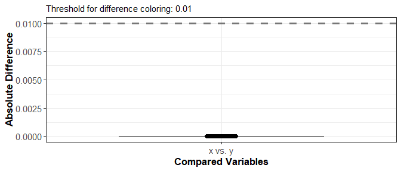

```r
# Compare loadings from SPSS and EFAtools::EFA with type = "SPSS"
COMPARE(EFA_SPSS_paf$unrot_loadings, SPSS_27$DOSPERT$paf_load)
```

```
#> Mean [min, max] absolute difference:  0.0000 [ 0.0000,  0.0000]
#> Median absolute difference:  0.0000
#> Max decimals where all numbers are equal: 13
#> Minimum number of decimals provided: 18
#>
#>        F1      F2      F3      F4      F5      F6      F7      F8      F9     F10
#> 01_s  0.0000 -0.0000  0.0000 -0.0000 -0.0000  0.0000  0.0000  0.0000  0.0000  0.0000
#> 02_r -0.0000  0.0000 -0.0000  0.0000  0.0000 -0.0000  0.0000  0.0000 -0.0000 -0.0000
#> 03_g  0.0000 -0.0000 -0.0000  0.0000  0.0000  0.0000  0.0000 -0.0000  0.0000  0.0000
#> 04_h -0.0000  0.0000  0.0000 -0.0000  0.0000  0.0000 -0.0000 -0.0000 -0.0000  0.0000
#> 05_e  0.0000 -0.0000  0.0000 -0.0000  0.0000 -0.0000  0.0000  0.0000 -0.0000 -0.0000
#> 06_r  0.0000 -0.0000 -0.0000  0.0000  0.0000 -0.0000  0.0000  0.0000  0.0000 -0.0000
#> 07_i  0.0000  0.0000  0.0000  0.0000 -0.0000 -0.0000  0.0000  0.0000 -0.0000  0.0000
#> 08_h  0.0000 -0.0000 -0.0000  0.0000 -0.0000  0.0000  0.0000 -0.0000 -0.0000  0.0000
#> 09_e  0.0000 -0.0000 -0.0000  0.0000  0.0000 -0.0000  0.0000  0.0000 -0.0000  0.0000
#> 10_s  0.0000  0.0000  0.0000 -0.0000 -0.0000  0.0000  0.0000  0.0000 -0.0000  0.0000
#> 11_g -0.0000  0.0000 -0.0000 -0.0000 -0.0000  0.0000 -0.0000 -0.0000 -0.0000 -0.0000
#> 12_e  0.0000 -0.0000 -0.0000 -0.0000 -0.0000  0.0000 -0.0000 -0.0000 -0.0000  0.0000
#> 13_e -0.0000  0.0000  0.0000 -0.0000 -0.0000  0.0000  0.0000  0.0000  0.0000 -0.0000
#> 14_e  0.0000 -0.0000  0.0000 -0.0000  0.0000 -0.0000  0.0000 -0.0000  0.0000 -0.0000
#> 15_r -0.0000  0.0000 -0.0000  0.0000  0.0000 -0.0000  0.0000  0.0000 -0.0000  0.0000
#> 16_s  0.0000  0.0000  0.0000  0.0000 -0.0000  0.0000  0.0000  0.0000  0.0000 -0.0000
#> 17_r  0.0000 -0.0000 -0.0000  0.0000  0.0000 -0.0000  0.0000 -0.0000  0.0000  0.0000
#> 18_i  0.0000 -0.0000  0.0000 -0.0000  0.0000 -0.0000  0.0000  0.0000 -0.0000 -0.0000
#> 19_s -0.0000  0.0000  0.0000 -0.0000  0.0000  0.0000 -0.0000  0.0000  0.0000  0.0000
#> 20_e  0.0000 -0.0000  0.0000 -0.0000  0.0000  0.0000  0.0000 -0.0000  0.0000 -0.0000
#> 21_r -0.0000  0.0000 -0.0000 -0.0000  0.0000  0.0000 -0.0000 -0.0000  0.0000 -0.0000
#> 22_g  0.0000 -0.0000 -0.0000 -0.0000 -0.0000  0.0000 -0.0000 -0.0000  0.0000  0.0000
#> 23_s  0.0000  0.0000  0.0000 -0.0000 -0.0000  0.0000 -0.0000  0.0000  0.0000  0.0000
#> 24_i -0.0000  0.0000  0.0000 -0.0000 -0.0000  0.0000 -0.0000 -0.0000  0.0000  0.0000
#> 25_e  0.0000  0.0000  0.0000 -0.0000  0.0000  0.0000  0.0000  0.0000 -0.0000 -0.0000
#> 26_s  0.0000 -0.0000 -0.0000  0.0000  0.0000  0.0000  0.0000  0.0000 -0.0000  0.0000
#> 27_h  0.0000 -0.0000 -0.0000  0.0000 -0.0000  0.0000 -0.0000 -0.0000  0.0000  0.0000
#> 28_e  0.0000 -0.0000  0.0000  0.0000  0.0000 -0.0000  0.0000 -0.0000 -0.0000 -0.0000
#> 29_h  0.0000  0.0000 -0.0000 -0.0000 -0.0000 -0.0000 -0.0000  0.0000  0.0000  0.0000
#> 30_i  0.0000  0.0000  0.0000  0.0000 -0.0000 -0.0000  0.0000  0.0000 -0.0000 -0.0000
#> 31_r -0.0000  0.0000 -0.0000  0.0000  0.0000 -0.0000 -0.0000 -0.0000  0.0000 -0.0000
#> 32_h  0.0000  0.0000 -0.0000 -0.0000  0.0000 -0.0000  0.0000  0.0000  0.0000  0.0000
#> 33_g  0.0000 -0.0000 -0.0000  0.0000  0.0000  0.0000  0.0000  0.0000 -0.0000 -0.0000
#> 34_s  0.0000 -0.0000 -0.0000  0.0000  0.0000 -0.0000 -0.0000  0.0000  0.0000  0.0000
#> 35_s  0.0000  0.0000  0.0000  0.0000 -0.0000  0.0000 -0.0000  0.0000  0.0000  0.0000
#> 36_h  0.0000  0.0000  0.0000 -0.0000 -0.0000 -0.0000 -0.0000  0.0000  0.0000 -0.0000
#> 37_r  0.0000 -0.0000  0.0000  0.0000 -0.0000 -0.0000  0.0000 -0.0000 -0.0000  0.0000
#> 38_r  0.0000 -0.0000 -0.0000  0.0000 -0.0000 -0.0000 -0.0000 -0.0000 -0.0000 -0.0000
#> 39_h  0.0000 -0.0000 -0.0000  0.0000 -0.0000 -0.0000  0.0000 -0.0000  0.0000 -0.0000
#> 40_h  0.0000 -0.0000 -0.0000  0.0000 -0.0000 -0.0000  0.0000 -0.0000 -0.0000 -0.0000
```

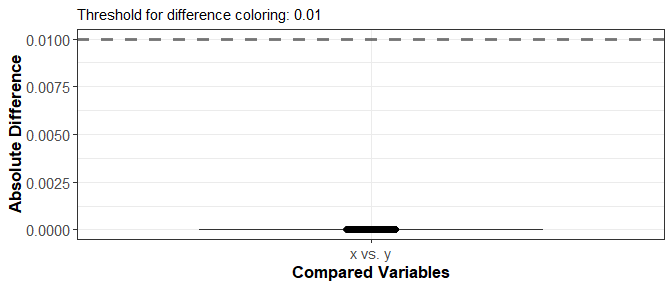

To see that this close match was not trivial, we can look at the match between the original R `psych` and `SPSS` solutions.

```r
# Compare loadings from psych::fa and SPSS
COMPARE(psych_paf$loadings, SPSS_27$DOSPERT$paf_load)
```

```
#> Mean [min, max] absolute difference:  0.0002 [ 0.0000,  0.0022]
#> Median absolute difference:  0.0001
#> Max decimals where all numbers are equal: 1
#> Minimum number of decimals provided: 18
#>
#>       PA1     PA2     PA3     PA4     PA5     PA6     PA7     PA8     PA9     PA10
#> 01_s  0.0000 -0.0000 -0.0001  0.0000  0.0001 -0.0002  0.0001 -0.0000 -0.0003  0.0002
#> 02_r  0.0000 -0.0000 -0.0000  0.0000 -0.0001 -0.0002  0.0000  0.0001  0.0004 -0.0000
#> 03_g -0.0000  0.0000  0.0000 -0.0000 -0.0001 -0.0001 -0.0001  0.0000  0.0001  0.0001
#> 04_h  0.0000 -0.0000 -0.0000 -0.0000 -0.0000 -0.0000 -0.0001  0.0001  0.0014 -0.0008
#> 05_e  0.0000  0.0000 -0.0001 -0.0001 -0.0001  0.0003 -0.0002 -0.0001  0.0007  0.0005
#> 06_r  0.0000 -0.0000 -0.0000  0.0000 -0.0001  0.0000  0.0001 -0.0000 -0.0007  0.0002
#> 07_i  0.0000 -0.0000  0.0000  0.0001  0.0001 -0.0001  0.0001 -0.0000  0.0006 -0.0004
#> 08_h  0.0000  0.0000 -0.0000 -0.0000  0.0001  0.0001 -0.0006  0.0000  0.0022 -0.0001
#> 09_e -0.0000  0.0000 -0.0000 -0.0001 -0.0001  0.0001  0.0001 -0.0000 -0.0002 -0.0000
#> 10_s  0.0000 -0.0000 -0.0001 -0.0000  0.0001 -0.0001  0.0001 -0.0000  0.0006 -0.0001
#> 11_g  0.0000  0.0000  0.0000 -0.0001 -0.0001  0.0000 -0.0003 -0.0000  0.0001  0.0004
#> 12_e  0.0000  0.0000 -0.0000 -0.0000  0.0001 -0.0002  0.0005  0.0002  0.0012 -0.0012
#> 13_e  0.0000  0.0000 -0.0001 -0.0001 -0.0001  0.0003 -0.0001 -0.0001 -0.0001  0.0005
#> 14_e  0.0000  0.0000 -0.0000 -0.0001 -0.0001  0.0003 -0.0002 -0.0001  0.0003  0.0005
#> 15_r  0.0000 -0.0000 -0.0001 -0.0000 -0.0001 -0.0000 -0.0000 -0.0000 -0.0001  0.0001
#> 16_s  0.0000 -0.0000 -0.0001 -0.0000  0.0001 -0.0001 -0.0002 -0.0000  0.0003  0.0003
#> 17_r  0.0000 -0.0000  0.0000  0.0000 -0.0000  0.0000 -0.0000 -0.0000 -0.0005  0.0004
#> 18_i  0.0000 -0.0000  0.0000  0.0000  0.0000 -0.0001  0.0003 -0.0000 -0.0001 -0.0003
#> 19_s  0.0000 -0.0000 -0.0000 -0.0000 -0.0000 -0.0002  0.0004  0.0000 -0.0010 -0.0002
#> 20_e  0.0000 -0.0000 -0.0001  0.0000 -0.0001  0.0002 -0.0009  0.0000 -0.0004  0.0011
#> 21_r -0.0000 -0.0000 -0.0000  0.0001 -0.0000  0.0000 -0.0000  0.0000 -0.0006  0.0003
#> 22_g  0.0000  0.0000  0.0001 -0.0000 -0.0000 -0.0001 -0.0001  0.0000  0.0002 -0.0000
#> 23_s -0.0000 -0.0000 -0.0000 -0.0000  0.0000 -0.0002  0.0006 -0.0000 -0.0009 -0.0004
#> 24_i  0.0000 -0.0000 -0.0000  0.0001  0.0001 -0.0002  0.0002  0.0001  0.0001 -0.0004
#> 25_e -0.0000  0.0000 -0.0001 -0.0001 -0.0001  0.0001  0.0000 -0.0000  0.0007 -0.0003
#> 26_s  0.0000 -0.0000 -0.0001 -0.0000  0.0000 -0.0002  0.0003  0.0000  0.0003 -0.0006
#> 27_h -0.0002  0.0002  0.0007  0.0003  0.0005 -0.0012  0.0022  0.0003 -0.0019 -0.0013
#> 28_e  0.0000 -0.0000 -0.0001 -0.0001 -0.0001  0.0001 -0.0001 -0.0000 -0.0005  0.0005
#> 29_h -0.0000  0.0000  0.0001 -0.0000  0.0001  0.0002 -0.0005 -0.0001 -0.0009 -0.0002
#> 30_i  0.0000 -0.0000 -0.0000  0.0001  0.0001 -0.0000 -0.0001 -0.0000  0.0000  0.0001
#> 31_r  0.0000 -0.0000  0.0000  0.0001 -0.0000  0.0000  0.0002  0.0000 -0.0004  0.0000
#> 32_h  0.0000 -0.0000  0.0000 -0.0001 -0.0001  0.0003  0.0003 -0.0002 -0.0014 -0.0001
#> 33_g  0.0000  0.0000  0.0000 -0.0001 -0.0001  0.0001 -0.0002 -0.0001 -0.0004  0.0004
#> 34_s  0.0000 -0.0000 -0.0000 -0.0000 -0.0000  0.0001 -0.0000 -0.0001 -0.0008  0.0001
#> 35_s  0.0000 -0.0000 -0.0001  0.0000  0.0001 -0.0002  0.0003 -0.0000 -0.0010 -0.0002
#> 36_h -0.0000  0.0000  0.0000  0.0000  0.0001  0.0001 -0.0002 -0.0001 -0.0001  0.0002
#> 37_r -0.0000 -0.0000  0.0000  0.0001  0.0001  0.0001 -0.0001 -0.0001  0.0010 -0.0002
#> 38_r  0.0000 -0.0000  0.0001  0.0001  0.0001  0.0000  0.0001  0.0001  0.0007 -0.0003
#> 39_h  0.0000 -0.0000 -0.0000  0.0000  0.0001  0.0000 -0.0004  0.0000  0.0006  0.0000
#> 40_h  0.0000  0.0000 -0.0000 -0.0000  0.0001  0.0004 -0.0010 -0.0001  0.0003  0.0011
```

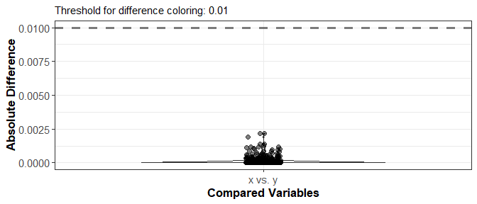

We can see that the solutions are slightly different, especially for the 9th and 10th factor. Although the differences are very small here, they can get quite large for other data sets, or get larger after rotation (see below).

## Varimax Rotation

Now we confirmed the replication of PAF results without rotation, we can continue to compare rotated factor solutions. We start by comparing varimax rotated PAF solutions.

```r
## Fit the models

# EFAtools::EFA with type = "psych" with varimax rotation
EFA_psych_var <- EFA(DOSPERT$cormat, n_factors = 10, N = DOSPERT$N,
                     type = "psych", rotation = "varimax")
# EFAtools::EFA with type = "SPSS" with varimax rotation
EFA_SPSS_var <- EFA(DOSPERT$cormat, n_factors = 10, N = DOSPERT$N,
                    type = "SPSS", rotation = "varimax")
# psych::fa with varimax rotation
psych_var <- psych::fa(DOSPERT$cormat, nfactors = 10, n.obs = DOSPERT$N,
                       fm = "pa", rotate = "varimax")

## Check replication of results

# Compare loadings from psych::fa and EFAtools::EFA with type = "psych"
COMPARE(EFA_psych_var$rot_loadings, psych_var$loadings)
```

```
#> Mean [min, max] absolute difference:  0.0000 [ 0.0000,  0.0000]
#> Median absolute difference:  0.0000
#> Max decimals where all numbers are equal: 12
#> Minimum number of decimals provided: 17
#>
#>        F1      F3      F2      F4      F5      F8      F6      F7      F9     F10
#> 01_s -0.0000  0.0000 -0.0000 -0.0000 -0.0000 -0.0000  0.0000 -0.0000 -0.0000 -0.0000
#> 02_r  0.0000  0.0000 -0.0000 -0.0000 -0.0000  0.0000 -0.0000 -0.0000 -0.0000  0.0000
#> 03_g -0.0000 -0.0000 -0.0000 -0.0000  0.0000 -0.0000  0.0000 -0.0000 -0.0000  0.0000
#> 04_h  0.0000  0.0000 -0.0000 -0.0000  0.0000 -0.0000  0.0000 -0.0000 -0.0000  0.0000
#> 05_e  0.0000  0.0000 -0.0000 -0.0000  0.0000  0.0000  0.0000 -0.0000 -0.0000 -0.0000
#> 06_r -0.0000  0.0000 -0.0000 -0.0000  0.0000 -0.0000 -0.0000  0.0000  0.0000 -0.0000
#> 07_i -0.0000 -0.0000  0.0000  0.0000 -0.0000 -0.0000  0.0000  0.0000  0.0000  0.0000
#> 08_h  0.0000  0.0000 -0.0000  0.0000 -0.0000 -0.0000  0.0000 -0.0000  0.0000  0.0000
#> 09_e  0.0000  0.0000 -0.0000 -0.0000  0.0000 -0.0000 -0.0000  0.0000  0.0000  0.0000
#> 10_s  0.0000  0.0000  0.0000 -0.0000 -0.0000  0.0000  0.0000 -0.0000  0.0000 -0.0000
#> 11_g  0.0000 -0.0000  0.0000 -0.0000 -0.0000 -0.0000 -0.0000  0.0000  0.0000  0.0000
#> 12_e  0.0000  0.0000 -0.0000 -0.0000  0.0000 -0.0000 -0.0000 -0.0000  0.0000  0.0000
#> 13_e  0.0000 -0.0000  0.0000  0.0000  0.0000 -0.0000 -0.0000  0.0000  0.0000 -0.0000
#> 14_e  0.0000 -0.0000  0.0000  0.0000  0.0000  0.0000  0.0000  0.0000  0.0000 -0.0000
#> 15_r -0.0000  0.0000  0.0000 -0.0000  0.0000  0.0000 -0.0000  0.0000 -0.0000 -0.0000
#> 16_s  0.0000  0.0000  0.0000 -0.0000 -0.0000  0.0000  0.0000 -0.0000 -0.0000 -0.0000
#> 17_r -0.0000  0.0000  0.0000  0.0000  0.0000 -0.0000  0.0000  0.0000  0.0000 -0.0000
#> 18_i  0.0000 -0.0000 -0.0000 -0.0000  0.0000  0.0000 -0.0000  0.0000  0.0000  0.0000
#> 19_s -0.0000 -0.0000  0.0000  0.0000  0.0000  0.0000 -0.0000  0.0000  0.0000 -0.0000
#> 20_e  0.0000  0.0000 -0.0000  0.0000 -0.0000 -0.0000  0.0000  0.0000 -0.0000  0.0000
#> 21_r -0.0000  0.0000 -0.0000  0.0000  0.0000 -0.0000 -0.0000  0.0000  0.0000 -0.0000
#> 22_g -0.0000 -0.0000  0.0000  0.0000  0.0000 -0.0000  0.0000  0.0000 -0.0000 -0.0000
#> 23_s  0.0000  0.0000 -0.0000 -0.0000  0.0000  0.0000 -0.0000  0.0000  0.0000 -0.0000
#> 24_i -0.0000 -0.0000 -0.0000  0.0000  0.0000 -0.0000  0.0000  0.0000  0.0000 -0.0000
#> 25_e  0.0000 -0.0000 -0.0000 -0.0000  0.0000  0.0000  0.0000  0.0000  0.0000 -0.0000
#> 26_s  0.0000  0.0000  0.0000 -0.0000  0.0000 -0.0000  0.0000  0.0000  0.0000 -0.0000
#> 27_h  0.0000  0.0000 -0.0000 -0.0000  0.0000 -0.0000  0.0000  0.0000 -0.0000 -0.0000
#> 28_e -0.0000 -0.0000 -0.0000  0.0000  0.0000 -0.0000 -0.0000  0.0000 -0.0000  0.0000
#> 29_h -0.0000 -0.0000  0.0000 -0.0000  0.0000  0.0000  0.0000  0.0000 -0.0000 -0.0000
#> 30_i -0.0000 -0.0000 -0.0000  0.0000  0.0000 -0.0000  0.0000  0.0000  0.0000  0.0000
#> 31_r -0.0000 -0.0000 -0.0000 -0.0000  0.0000  0.0000 -0.0000  0.0000  0.0000 -0.0000
#> 32_h -0.0000 -0.0000  0.0000 -0.0000  0.0000  0.0000 -0.0000  0.0000 -0.0000 -0.0000
#> 33_g  0.0000  0.0000  0.0000 -0.0000 -0.0000  0.0000 -0.0000  0.0000 -0.0000 -0.0000
#> 34_s -0.0000  0.0000  0.0000  0.0000  0.0000 -0.0000 -0.0000  0.0000  0.0000 -0.0000
#> 35_s -0.0000  0.0000 -0.0000 -0.0000  0.0000 -0.0000 -0.0000  0.0000  0.0000 -0.0000
#> 36_h  0.0000  0.0000 -0.0000 -0.0000  0.0000 -0.0000  0.0000 -0.0000  0.0000 -0.0000
#> 37_r  0.0000  0.0000 -0.0000 -0.0000  0.0000 -0.0000  0.0000 -0.0000 -0.0000  0.0000
#> 38_r  0.0000  0.0000 -0.0000 -0.0000  0.0000 -0.0000  0.0000 -0.0000 -0.0000  0.0000
#> 39_h  0.0000  0.0000 -0.0000  0.0000  0.0000 -0.0000 -0.0000  0.0000  0.0000  0.0000
#> 40_h  0.0000  0.0000  0.0000 -0.0000 -0.0000 -0.0000 -0.0000 -0.0000  0.0000  0.0000
```

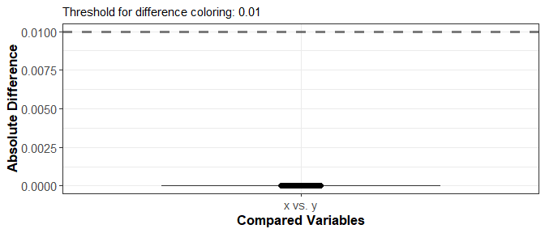

```r
# Compare loadings from SPSS and EFAtools::EFA with type = "SPSS"
COMPARE(EFA_SPSS_var$rot_loadings, SPSS_27$DOSPERT$var_load)
```

```
#> Mean [min, max] absolute difference:  0.0000 [ 0.0000,  0.0000]
#> Median absolute difference:  0.0000
#> Max decimals where all numbers are equal: 2
#> Minimum number of decimals provided: 18
#>
#>        F1      F3      F2      F4      F5      F8      F6      F7      F9     F10
#> 01_s  0.0000 -0.0000 -0.0000 -0.0000 -0.0000 -0.0000  0.0000 -0.0000 -0.0000 -0.0000
#> 02_r -0.0000  0.0000  0.0000 -0.0000  0.0000 -0.0000  0.0000 -0.0000 -0.0000 -0.0000
#> 03_g  0.0000  0.0000  0.0000 -0.0000  0.0000 -0.0000  0.0000 -0.0000  0.0000 -0.0000
#> 04_h -0.0000 -0.0000  0.0000 -0.0000 -0.0000  0.0000  0.0000 -0.0000  0.0000  0.0000
#> 05_e  0.0000 -0.0000  0.0000 -0.0000 -0.0000  0.0000  0.0000 -0.0000 -0.0000 -0.0000
#> 06_r  0.0000  0.0000 -0.0000 -0.0000  0.0000 -0.0000  0.0000 -0.0000 -0.0000 -0.0000
#> 07_i -0.0000  0.0000 -0.0000  0.0000  0.0000 -0.0000 -0.0000  0.0000  0.0000 -0.0000
#> 08_h -0.0000 -0.0000  0.0000 -0.0000 -0.0000  0.0000  0.0000 -0.0000  0.0000  0.0000
#> 09_e  0.0000 -0.0000  0.0000 -0.0000  0.0000  0.0000  0.0000 -0.0000  0.0000 -0.0000
#> 10_s  0.0000 -0.0000 -0.0000 -0.0000 -0.0000  0.0000  0.0000 -0.0000 -0.0000 -0.0000
#> 11_g  0.0000 -0.0000  0.0000 -0.0000 -0.0000 -0.0000  0.0000 -0.0000 -0.0000 -0.0000
#> 12_e -0.0000 -0.0000  0.0000 -0.0000  0.0000  0.0000  0.0000 -0.0000  0.0000 -0.0000
#> 13_e  0.0000 -0.0000  0.0000 -0.0000 -0.0000  0.0000  0.0000 -0.0000  0.0000 -0.0000
#> 14_e -0.0000 -0.0000  0.0000 -0.0000 -0.0000  0.0000  0.0000 -0.0000  0.0000  0.0000
#> 15_r -0.0000  0.0000  0.0000 -0.0000  0.0000 -0.0000  0.0000 -0.0000 -0.0000 -0.0000
#> 16_s -0.0000 -0.0000 -0.0000 -0.0000 -0.0000  0.0000  0.0000 -0.0000 -0.0000 -0.0000
#> 17_r  0.0000  0.0000  0.0000 -0.0000  0.0000 -0.0000  0.0000 -0.0000 -0.0000 -0.0000
#> 18_i -0.0000  0.0000 -0.0000  0.0000  0.0000 -0.0000  0.0000  0.0000  0.0000 -0.0000
#> 19_s  0.0000  0.0000 -0.0000  0.0000  0.0000 -0.0000 -0.0000  0.0000  0.0000 -0.0000
#> 20_e -0.0000 -0.0000  0.0000 -0.0000  0.0000  0.0000 -0.0000 -0.0000  0.0000  0.0000
#> 21_r -0.0000  0.0000  0.0000  0.0000  0.0000 -0.0000 -0.0000  0.0000  0.0000 -0.0000
#> 22_g  0.0000  0.0000  0.0000 -0.0000  0.0000 -0.0000  0.0000 -0.0000  0.0000 -0.0000
#> 23_s  0.0000  0.0000 -0.0000  0.0000  0.0000 -0.0000  0.0000  0.0000 -0.0000 -0.0000
#> 24_i -0.0000  0.0000  0.0000  0.0000  0.0000 -0.0000 -0.0000  0.0000  0.0000 -0.0000
#> 25_e  0.0000 -0.0000  0.0000 -0.0000 -0.0000  0.0000  0.0000 -0.0000  0.0000 -0.0000
#> 26_s -0.0000  0.0000 -0.0000 -0.0000  0.0000  0.0000  0.0000 -0.0000 -0.0000 -0.0000
#> 27_h -0.0000  0.0000 -0.0000 -0.0000  0.0000 -0.0000  0.0000  0.0000  0.0000 -0.0000
#> 28_e -0.0000 -0.0000  0.0000 -0.0000  0.0000  0.0000  0.0000 -0.0000  0.0000 -0.0000
#> 29_h  0.0000 -0.0000  0.0000 -0.0000 -0.0000  0.0000  0.0000 -0.0000 -0.0000 -0.0000
#> 30_i -0.0000  0.0000  0.0000  0.0000  0.0000  0.0000 -0.0000  0.0000  0.0000  0.0000
#> 31_r  0.0000  0.0000 -0.0000 -0.0000  0.0000 -0.0000  0.0000 -0.0000 -0.0000 -0.0000
#> 32_h  0.0000 -0.0000  0.0000 -0.0000  0.0000 -0.0000  0.0000 -0.0000 -0.0000 -0.0000
#> 33_g  0.0000 -0.0000 -0.0000 -0.0000  0.0000 -0.0000  0.0000 -0.0000 -0.0000 -0.0000
#> 34_s  0.0000  0.0000  0.0000  0.0000  0.0000 -0.0000 -0.0000  0.0000  0.0000 -0.0000
#> 35_s  0.0000  0.0000 -0.0000  0.0000  0.0000 -0.0000 -0.0000  0.0000 -0.0000 -0.0000
#> 36_h  0.0000 -0.0000 -0.0000 -0.0000 -0.0000  0.0000  0.0000 -0.0000 -0.0000 -0.0000
#> 37_r  0.0000 -0.0000 -0.0000 -0.0000 -0.0000 -0.0000  0.0000 -0.0000 -0.0000 -0.0000
#> 38_r  0.0000 -0.0000 -0.0000 -0.0000 -0.0000 -0.0000  0.0000 -0.0000 -0.0000 -0.0000
#> 39_h -0.0000  0.0000  0.0000 -0.0000 -0.0000  0.0000  0.0000 -0.0000  0.0000  0.0000
#> 40_h -0.0000 -0.0000  0.0000 -0.0000 -0.0000  0.0000  0.0000 -0.0000  0.0000  0.0000
```

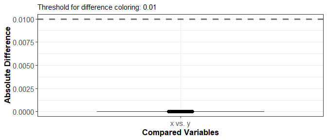

```r
## Compare original results (just to see the difference)

# Compare loadings from psych::fa and SPSS
COMPARE(psych_var$loadings, SPSS_27$DOSPERT$var_load)
```

```
#> Mean [min, max] absolute difference:  0.0005 [ 0.0000,  0.0033]
#> Median absolute difference:  0.0002
#> Max decimals where all numbers are equal: 0
#> Minimum number of decimals provided: 17
#>
#>       PA1     PA3     PA2     PA4     PA5     PA8     PA6     PA7     PA9     PA10
#> 01_s  0.0001 -0.0002 -0.0001 -0.0000  0.0001 -0.0002  0.0007 -0.0001 -0.0004 -0.0028
#> 02_r  0.0001  0.0026 -0.0002 -0.0001  0.0002 -0.0017 -0.0000 -0.0000  0.0002 -0.0004
#> 03_g -0.0001  0.0007 -0.0000 -0.0000  0.0002 -0.0004 -0.0001  0.0001  0.0002 -0.0002
#> 04_h -0.0002  0.0009 -0.0000 -0.0001 -0.0001 -0.0009 -0.0001 -0.0000  0.0009 -0.0003
#> 05_e -0.0001 -0.0001 -0.0001 -0.0000 -0.0006 -0.0003  0.0007 -0.0004  0.0000 -0.0017
#> 06_r  0.0001  0.0010 -0.0001 -0.0001  0.0010 -0.0019 -0.0002  0.0004  0.0001 -0.0015
#> 07_i -0.0001  0.0000  0.0000 -0.0001 -0.0000 -0.0002  0.0001 -0.0001  0.0002 -0.0007
#> 08_h -0.0003  0.0003 -0.0000 -0.0001 -0.0012 -0.0002  0.0005 -0.0008  0.0006  0.0005
#> 09_e  0.0001  0.0003  0.0000  0.0000  0.0009 -0.0012 -0.0003  0.0005  0.0003 -0.0014
#> 10_s -0.0001 -0.0002 -0.0001 -0.0001 -0.0007  0.0000  0.0010 -0.0005 -0.0001 -0.0024
#> 11_g -0.0001  0.0003 -0.0000 -0.0000  0.0001 -0.0005  0.0002 -0.0001  0.0000 -0.0007
#> 12_e -0.0001  0.0003  0.0000 -0.0001  0.0004 -0.0009 -0.0002  0.0003  0.0008 -0.0013
#> 13_e  0.0001  0.0006 -0.0000  0.0000  0.0006 -0.0005  0.0000  0.0004  0.0002 -0.0019
#> 14_e -0.0000  0.0002  0.0000  0.0000 -0.0000 -0.0002  0.0001  0.0001  0.0001 -0.0006
#> 15_r  0.0001  0.0028 -0.0002 -0.0001  0.0003 -0.0012  0.0001  0.0000  0.0002 -0.0012
#> 16_s  0.0000  0.0005 -0.0001 -0.0001 -0.0002 -0.0001  0.0008 -0.0004 -0.0002 -0.0025
#> 17_r  0.0002  0.0012 -0.0001 -0.0001  0.0007 -0.0022 -0.0001  0.0001 -0.0000 -0.0009
#> 18_i -0.0000 -0.0000 -0.0000 -0.0000  0.0005 -0.0008  0.0000  0.0002  0.0000 -0.0014
#> 19_s  0.0002  0.0008 -0.0000 -0.0000  0.0016 -0.0012 -0.0005  0.0008  0.0001 -0.0024
#> 20_e  0.0005  0.0011  0.0000  0.0000  0.0014 -0.0011 -0.0010  0.0005  0.0001  0.0004
#> 21_r  0.0002  0.0020 -0.0001 -0.0001  0.0014 -0.0030 -0.0007  0.0005  0.0004 -0.0010
#> 22_g -0.0001  0.0003  0.0000 -0.0000  0.0003 -0.0004 -0.0002  0.0001  0.0003  0.0001
#> 23_s  0.0001  0.0002  0.0000 -0.0000  0.0011 -0.0007 -0.0001  0.0007  0.0000 -0.0025
#> 24_i  0.0001  0.0002 -0.0000  0.0000  0.0003  0.0001 -0.0003  0.0001 -0.0000 -0.0002
#> 25_e -0.0001  0.0006 -0.0000 -0.0000  0.0002 -0.0005  0.0000  0.0002  0.0006 -0.0013
#> 26_s -0.0000  0.0011 -0.0000 -0.0001  0.0006 -0.0006  0.0000  0.0004  0.0005 -0.0022
#> 27_h  0.0001  0.0001 -0.0000  0.0001  0.0004 -0.0004  0.0004  0.0001 -0.0027 -0.0008
#> 28_e  0.0003  0.0010  0.0000  0.0000  0.0016 -0.0013 -0.0009  0.0009  0.0004 -0.0012
#> 29_h -0.0002  0.0004  0.0000 -0.0000  0.0000 -0.0004  0.0007 -0.0005  0.0002 -0.0022
#> 30_i  0.0001  0.0002  0.0000  0.0000  0.0003 -0.0000 -0.0002 -0.0000 -0.0002 -0.0001
#> 31_r  0.0001  0.0012 -0.0002 -0.0002  0.0006 -0.0033  0.0002 -0.0000  0.0001 -0.0021
#> 32_h  0.0000  0.0009 -0.0000 -0.0000  0.0009 -0.0013  0.0001  0.0006  0.0001 -0.0018
#> 33_g -0.0000 -0.0001  0.0000  0.0000  0.0003 -0.0003  0.0002  0.0001 -0.0000 -0.0010
#> 34_s  0.0001  0.0004  0.0001 -0.0000  0.0011 -0.0006 -0.0005  0.0006  0.0002 -0.0009
#> 35_s  0.0002  0.0009  0.0000 -0.0001  0.0019 -0.0014 -0.0005  0.0009  0.0003 -0.0032
#> 36_h -0.0000  0.0001 -0.0000 -0.0001 -0.0003 -0.0005  0.0006 -0.0004 -0.0002 -0.0009
#> 37_r -0.0002 -0.0005 -0.0001 -0.0002 -0.0004 -0.0029  0.0006 -0.0006  0.0004 -0.0016
#> 38_r -0.0001 -0.0001 -0.0000 -0.0002  0.0001 -0.0030  0.0003 -0.0003  0.0004 -0.0016
#> 39_h  0.0000  0.0012  0.0000 -0.0001  0.0004 -0.0014 -0.0003  0.0000  0.0006 -0.0003
#> 40_h  0.0001 -0.0003  0.0001 -0.0000 -0.0003 -0.0002  0.0002 -0.0004 -0.0001  0.0007
```

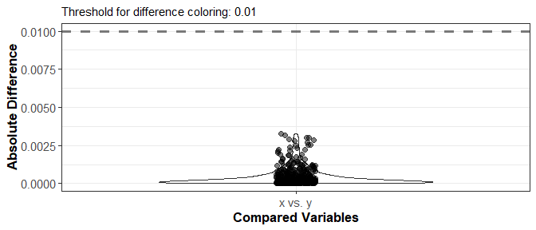

## Promax Rotation

Finally, we can do the same for promax rotated results as well.

```r
## Fit the models

# EFAtools::EFA with type = "psych" with promax rotation
EFA_psych_pro <- EFA(DOSPERT$cormat, n_factors = 10, N = DOSPERT$N,
                     type = "psych", rotation = "promax")
# EFAtools::EFA with type = "SPSS" with promax rotation
EFA_SPSS_pro <- EFA(DOSPERT$cormat, n_factors = 10, N = DOSPERT$N,
                    type = "SPSS", rotation = "promax")
# psych::fa with promax rotation
psych_pro <- psych::fa(DOSPERT$cormat, nfactors = 10, n.obs = DOSPERT$N,
                       fm = "pa", rotate = "Promax")

## Check replication of results

# Compare loadings from psych::fa and EFAtools::EFA with type = "psych"
COMPARE(EFA_psych_pro$rot_loadings, psych_pro$loadings)
```

```
#> Mean [min, max] absolute difference:  0.0000 [ 0.0000,  0.0000]
#> Median absolute difference:  0.0000
#> Max decimals where all numbers are equal: 11
#> Minimum number of decimals provided: 18
#>
#>        F1      F4      F3      F2      F8      F5      F9     F10      F7      F6
#> 01_s  0.0000 -0.0000  0.0000 -0.0000 -0.0000  0.0000 -0.0000 -0.0000 -0.0000  0.0000
#> 02_r  0.0000 -0.0000  0.0000 -0.0000  0.0000 -0.0000  0.0000  0.0000 -0.0000  0.0000
#> 03_g  0.0000  0.0000  0.0000 -0.0000 -0.0000  0.0000 -0.0000 -0.0000 -0.0000  0.0000
#> 04_h -0.0000  0.0000  0.0000 -0.0000 -0.0000 -0.0000  0.0000  0.0000 -0.0000  0.0000
#> 05_e  0.0000 -0.0000  0.0000  0.0000  0.0000 -0.0000 -0.0000  0.0000 -0.0000  0.0000
#> 06_r -0.0000 -0.0000  0.0000 -0.0000 -0.0000  0.0000  0.0000 -0.0000  0.0000 -0.0000
#> 07_i -0.0000  0.0000 -0.0000  0.0000 -0.0000 -0.0000  0.0000 -0.0000 -0.0000  0.0000
#> 08_h  0.0000  0.0000  0.0000  0.0000 -0.0000 -0.0000  0.0000  0.0000 -0.0000  0.0000
#> 09_e -0.0000 -0.0000  0.0000 -0.0000 -0.0000 -0.0000  0.0000  0.0000  0.0000 -0.0000
#> 10_s  0.0000 -0.0000  0.0000  0.0000 -0.0000 -0.0000  0.0000 -0.0000 -0.0000  0.0000
#> 11_g  0.0000 -0.0000  0.0000  0.0000 -0.0000 -0.0000  0.0000  0.0000  0.0000 -0.0000
#> 12_e -0.0000 -0.0000 -0.0000  0.0000 -0.0000  0.0000  0.0000 -0.0000 -0.0000 -0.0000
#> 13_e -0.0000  0.0000 -0.0000 -0.0000  0.0000  0.0000  0.0000  0.0000  0.0000 -0.0000
#> 14_e -0.0000  0.0000 -0.0000  0.0000  0.0000 -0.0000  0.0000  0.0000  0.0000  0.0000
#> 15_r  0.0000 -0.0000 -0.0000 -0.0000  0.0000 -0.0000 -0.0000 -0.0000  0.0000  0.0000
#> 16_s  0.0000  0.0000  0.0000  0.0000 -0.0000  0.0000 -0.0000 -0.0000 -0.0000  0.0000
#> 17_r -0.0000  0.0000  0.0000  0.0000 -0.0000  0.0000  0.0000 -0.0000  0.0000 -0.0000
#> 18_i  0.0000 -0.0000 -0.0000 -0.0000  0.0000 -0.0000  0.0000 -0.0000  0.0000 -0.0000
#> 19_s -0.0000  0.0000 -0.0000  0.0000  0.0000  0.0000 -0.0000 -0.0000 -0.0000 -0.0000
#> 20_e -0.0000 -0.0000 -0.0000 -0.0000 -0.0000  0.0000 -0.0000  0.0000  0.0000  0.0000
#> 21_r -0.0000  0.0000  0.0000  0.0000 -0.0000  0.0000  0.0000 -0.0000  0.0000 -0.0000
#> 22_g  0.0000  0.0000  0.0000  0.0000  0.0000  0.0000 -0.0000 -0.0000 -0.0000  0.0000
#> 23_s  0.0000  0.0000  0.0000  0.0000  0.0000  0.0000 -0.0000 -0.0000 -0.0000 -0.0000
#> 24_i -0.0000  0.0000 -0.0000  0.0000  0.0000  0.0000 -0.0000 -0.0000 -0.0000  0.0000
#> 25_e -0.0000  0.0000 -0.0000 -0.0000  0.0000 -0.0000  0.0000  0.0000  0.0000  0.0000
#> 26_s -0.0000  0.0000 -0.0000  0.0000 -0.0000  0.0000  0.0000 -0.0000  0.0000  0.0000
#> 27_h -0.0000 -0.0000  0.0000 -0.0000 -0.0000  0.0000  0.0000 -0.0000 -0.0000  0.0000
#> 28_e -0.0000 -0.0000 -0.0000 -0.0000 -0.0000  0.0000 -0.0000  0.0000  0.0000  0.0000
#> 29_h -0.0000  0.0000 -0.0000 -0.0000 -0.0000  0.0000 -0.0000 -0.0000  0.0000  0.0000
#> 30_i -0.0000 -0.0000  0.0000  0.0000 -0.0000 -0.0000 -0.0000  0.0000  0.0000  0.0000
#> 31_r -0.0000  0.0000  0.0000 -0.0000 -0.0000  0.0000  0.0000 -0.0000  0.0000 -0.0000
#> 32_h -0.0000 -0.0000 -0.0000 -0.0000 -0.0000  0.0000  0.0000 -0.0000  0.0000 -0.0000
#> 33_g  0.0000 -0.0000  0.0000  0.0000  0.0000 -0.0000 -0.0000 -0.0000  0.0000 -0.0000
#> 34_s -0.0000  0.0000  0.0000  0.0000  0.0000  0.0000  0.0000 -0.0000  0.0000 -0.0000
#> 35_s -0.0000  0.0000  0.0000 -0.0000 -0.0000  0.0000 -0.0000 -0.0000  0.0000 -0.0000
#> 36_h  0.0000 -0.0000  0.0000  0.0000 -0.0000  0.0000  0.0000 -0.0000  0.0000  0.0000
#> 37_r  0.0000 -0.0000  0.0000  0.0000 -0.0000 -0.0000 -0.0000 -0.0000 -0.0000  0.0000
#> 38_r  0.0000 -0.0000  0.0000  0.0000 -0.0000 -0.0000 -0.0000 -0.0000 -0.0000  0.0000
#> 39_h -0.0000  0.0000  0.0000 -0.0000 -0.0000  0.0000  0.0000  0.0000  0.0000  0.0000
#> 40_h  0.0000 -0.0000  0.0000  0.0000  0.0000  0.0000 -0.0000  0.0000  0.0000 -0.0000
```

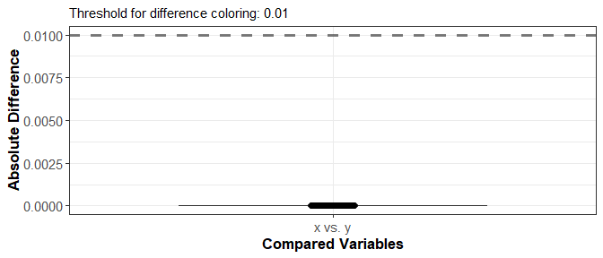

```r
# Compare loadings from SPSS and EFAtools::EFA with type = "SPSS"
COMPARE(EFA_SPSS_pro$rot_loadings, SPSS_27$DOSPERT$pro_load)
```

```
#> Mean [min, max] absolute difference:  0.0000 [ 0.0000,  0.0001]
#> Median absolute difference:  0.0000
#> Max decimals where all numbers are equal: 2
#> Minimum number of decimals provided: 18
#>
#>        F1      F3      F2      F4      F5      F8      F6      F7      F9     F10
#> 01_s  0.0000 -0.0000 -0.0000 -0.0000  0.0000  0.0000  0.0000 -0.0000 -0.0000 -0.0001
#> 02_r -0.0000  0.0000  0.0000  0.0000 -0.0000 -0.0000  0.0000  0.0000  0.0000  0.0000
#> 03_g  0.0000  0.0000 -0.0000  0.0000 -0.0000 -0.0000  0.0000  0.0000  0.0000 -0.0000
#> 04_h -0.0000  0.0000  0.0000 -0.0000 -0.0000 -0.0000  0.0000 -0.0000  0.0000  0.0000
#> 05_e  0.0000 -0.0000 -0.0000 -0.0000 -0.0000  0.0000  0.0000 -0.0000  0.0000  0.0000
#> 06_r -0.0000  0.0000 -0.0000  0.0000  0.0000 -0.0000 -0.0000  0.0000 -0.0000 -0.0000
#> 07_i  0.0000 -0.0000  0.0000  0.0000 -0.0000  0.0000  0.0000 -0.0000  0.0000 -0.0000
#> 08_h -0.0000 -0.0000  0.0000 -0.0000 -0.0000  0.0000 -0.0000 -0.0000  0.0000  0.0000
#> 09_e -0.0000  0.0000  0.0000 -0.0000  0.0000  0.0000 -0.0000 -0.0000  0.0000  0.0000
#> 10_s  0.0000 -0.0000 -0.0000 -0.0000  0.0000  0.0000  0.0000 -0.0000 -0.0000 -0.0000
#> 11_g  0.0000  0.0000 -0.0000  0.0000 -0.0000 -0.0000  0.0000 -0.0000 -0.0000 -0.0000
#> 12_e -0.0000 -0.0000 -0.0000  0.0000  0.0000  0.0000  0.0000  0.0000  0.0000 -0.0000
#> 13_e -0.0000 -0.0000  0.0000 -0.0000  0.0000  0.0000 -0.0000 -0.0000  0.0000  0.0000
#> 14_e -0.0000 -0.0000  0.0000 -0.0000 -0.0000  0.0000  0.0000 -0.0000  0.0000  0.0000
#> 15_r  0.0000  0.0000  0.0000  0.0000 -0.0000 -0.0000  0.0000 -0.0000 -0.0000 -0.0000
#> 16_s  0.0000 -0.0000 -0.0000 -0.0000  0.0000  0.0000  0.0000 -0.0000 -0.0000 -0.0000
#> 17_r -0.0000  0.0000 -0.0000  0.0000  0.0000 -0.0000 -0.0000  0.0000 -0.0000  0.0000
#> 18_i  0.0000  0.0000  0.0000  0.0000  0.0000  0.0000  0.0000 -0.0000  0.0000 -0.0000
#> 19_s -0.0000  0.0000 -0.0000  0.0000  0.0000 -0.0000 -0.0000  0.0000  0.0000 -0.0000
#> 20_e -0.0000  0.0000  0.0000 -0.0000  0.0000 -0.0000 -0.0000  0.0000 -0.0000  0.0001
#> 21_r -0.0000  0.0000  0.0000  0.0000  0.0000 -0.0000 -0.0000  0.0000 -0.0000  0.0000
#> 22_g -0.0000  0.0000 -0.0000  0.0000  0.0000 -0.0000 -0.0000  0.0000  0.0000  0.0000
#> 23_s -0.0000  0.0000 -0.0000  0.0000  0.0000  0.0000  0.0000  0.0000  0.0000 -0.0001
#> 24_i -0.0000  0.0000  0.0000  0.0000 -0.0000  0.0000 -0.0000  0.0000  0.0000 -0.0000
#> 25_e -0.0000 -0.0000  0.0000 -0.0000 -0.0000  0.0000  0.0000 -0.0000  0.0000  0.0000
#> 26_s -0.0000  0.0000 -0.0000 -0.0000  0.0000 -0.0000  0.0000 -0.0000  0.0000 -0.0000
#> 27_h -0.0000 -0.0000 -0.0000  0.0000  0.0000  0.0000  0.0000 -0.0000  0.0000 -0.0000
#> 28_e -0.0000  0.0000  0.0000 -0.0000  0.0000 -0.0000 -0.0000  0.0000  0.0000  0.0000
#> 29_h  0.0000  0.0000 -0.0000 -0.0000 -0.0000  0.0000  0.0000 -0.0000 -0.0000 -0.0000
#> 30_i -0.0000  0.0000  0.0000  0.0000 -0.0000 -0.0000 -0.0000 -0.0000 -0.0000  0.0000
#> 31_r  0.0000  0.0000 -0.0000 -0.0000  0.0000 -0.0000  0.0000  0.0000 -0.0000 -0.0000
#> 32_h  0.0000  0.0000 -0.0000 -0.0000  0.0000 -0.0000 -0.0000 -0.0000 -0.0000 -0.0000
#> 33_g  0.0000 -0.0000 -0.0000  0.0000  0.0000  0.0000 -0.0000 -0.0000 -0.0000 -0.0000
#> 34_s -0.0000  0.0000  0.0000  0.0000  0.0000  0.0000 -0.0000 -0.0000 -0.0000 -0.0000
#> 35_s -0.0000  0.0000 -0.0000  0.0000  0.0000 -0.0000 -0.0000  0.0000 -0.0000 -0.0001
#> 36_h  0.0000 -0.0000  0.0000 -0.0000 -0.0000  0.0000 -0.0000 -0.0000 -0.0000  0.0000
#> 37_r  0.0000  0.0000 -0.0000 -0.0000 -0.0000 -0.0000  0.0000 -0.0000  0.0000 -0.0000
#> 38_r  0.0000  0.0000 -0.0000 -0.0000  0.0000 -0.0000  0.0000  0.0000  0.0000 -0.0000
#> 39_h -0.0000  0.0000  0.0000  0.0000  0.0000 -0.0000 -0.0000 -0.0000  0.0000  0.0000
#> 40_h -0.0000 -0.0000  0.0000 -0.0000 -0.0000  0.0000 -0.0000 -0.0000 -0.0000  0.0001
```

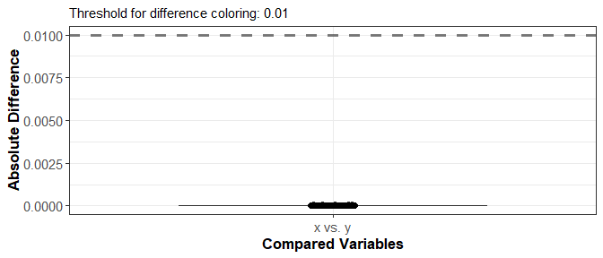

```r
## Compare original results (just to see the difference)

# Compare loadings from psych::fa and SPSS
COMPARE(psych_pro$loadings, SPSS_27$DOSPERT$pro_load)
```

```
#> Mean [min, max] absolute difference:  0.0196 [ 0.0000,  0.2404]
#> Median absolute difference:  0.0114
#> Max decimals where all numbers are equal: 0
#> Minimum number of decimals provided: 18
#>
#>       PA1     PA3     PA2     PA4     PA8     PA5     PA10    PA7     PA6     PA9
#> 01_s  0.0057  0.0068 -0.0101 -0.0131  0.0059  0.0211  0.0017 -0.0058 -0.0103 -0.0060
#> 02_r -0.0027  0.0070  0.0072  0.0223 -0.0818  0.0354  0.1056 -0.0108  0.0499 -0.0061
#> 03_g -0.0179 -0.0183 -0.0107  0.0324 -0.0152  0.0157  0.0087 -0.0040  0.0082 -0.0027
#> 04_h -0.0149 -0.0010  0.0070  0.0142 -0.0284  0.0135  0.0730 -0.0024  0.0218 -0.0012
#> 05_e -0.0656  0.0122 -0.0176 -0.0114  0.0014 -0.0626  0.0710  0.0299 -0.0118 -0.0104
#> 06_r  0.0152 -0.0044 -0.0083 -0.0013 -0.0153  0.0129 -0.0155  0.0018  0.0134 -0.0008
#> 07_i -0.0176  0.0037 -0.0190  0.0158  0.0014 -0.0115  0.0189  0.0050 -0.0101 -0.0003
#> 08_h -0.0363  0.0057  0.0039  0.0236 -0.0212  0.0058  0.1465 -0.0105 -0.0164 -0.0060
#> 09_e  0.0103 -0.0087 -0.0068 -0.0088  0.0114 -0.0086  0.0169  0.0089  0.0162 -0.0019
#> 10_s -0.0360  0.0155 -0.0119 -0.0067 -0.0069 -0.0047  0.0252  0.0082 -0.0185 -0.0068
#> 11_g -0.0233 -0.0165 -0.0163  0.0274 -0.0031  0.0086  0.0225 -0.0027 -0.0098 -0.0052
#> 12_e -0.0211 -0.0020 -0.0037  0.0155 -0.0063 -0.0031  0.0292 -0.0052  0.0338  0.0019
#> 13_e -0.0037 -0.0049 -0.0062 -0.0176 -0.0013 -0.0117  0.0407  0.0266  0.0081 -0.0080
#> 14_e -0.0257 -0.0036 -0.0070 -0.0031  0.0012 -0.0282  0.0522  0.0216 -0.0023 -0.0063
#> 15_r -0.0071  0.0027  0.0053  0.0119 -0.0842  0.0423  0.0352  0.0164  0.0323 -0.0063
#> 16_s  0.0042  0.0064 -0.0037  0.0004 -0.0225  0.0442  0.0653 -0.0097 -0.0060 -0.0095
#> 17_r  0.0131 -0.0050 -0.0050  0.0067 -0.0213  0.0196  0.0084 -0.0026  0.0037 -0.0006
#> 18_i -0.0197 -0.0028 -0.0241  0.0098  0.0111 -0.0207 -0.0240  0.0115 -0.0046  0.0001
#> 19_s  0.0405 -0.0102 -0.0078 -0.0061 -0.0038  0.0313 -0.0472 -0.0025  0.0339  0.0005
#> 20_e  0.1080 -0.0234  0.0164  0.0044 -0.0045  0.0744  0.2017 -0.0432  0.0389 -0.0093
#> 21_r  0.0460 -0.0071  0.0012  0.0070 -0.0399  0.0457  0.0219 -0.0121  0.0280  0.0006
#> 22_g -0.0134 -0.0224 -0.0111  0.0331 -0.0006  0.0145 -0.0118 -0.0048 -0.0006  0.0001
#> 23_s  0.0258 -0.0055 -0.0057 -0.0130  0.0065  0.0254 -0.0827  0.0016  0.0166  0.0021
#> 24_i  0.0085 -0.0026 -0.0140  0.0204  0.0009  0.0057  0.0315 -0.0031  0.0062  0.0004
#> 25_e -0.0290  0.0017 -0.0053 -0.0045 -0.0120 -0.0233  0.0447  0.0205  0.0189 -0.0047
#> 26_s  0.0069 -0.0049  0.0017 -0.0005 -0.0260  0.0398 -0.0189  0.0080  0.0203 -0.0014
#> 27_h -0.0351 -0.0031  0.0042  0.0199 -0.0020 -0.0017 -0.0848  0.0067  0.0230  0.0079
#> 28_e  0.0583 -0.0170  0.0015 -0.0061 -0.0021  0.0254  0.0972 -0.0124  0.0505 -0.0065
#> 29_h -0.0537 -0.0080 -0.0132 -0.0260  0.0082 -0.0178 -0.2404  0.0835 -0.0735  0.0061
#> 30_i  0.0121 -0.0029 -0.0124  0.0158  0.0014  0.0042  0.0606 -0.0016 -0.0018 -0.0024
#> 31_r -0.0143  0.0139 -0.0165 -0.0040 -0.0278 -0.0122 -0.0051  0.0024  0.0040 -0.0006
#> 32_h -0.0099 -0.0146 -0.0086 -0.0207 -0.0001  0.0069 -0.2107  0.0606 -0.0429  0.0069
#> 33_g -0.0164 -0.0177 -0.0152  0.0100  0.0132  0.0017 -0.0483  0.0102 -0.0197 -0.0023
#> 34_s  0.0421 -0.0161  0.0032 -0.0113  0.0078  0.0346 -0.0747  0.0081 -0.0006  0.0033
#> 35_s  0.0770 -0.0171  0.0003 -0.0110 -0.0011  0.0824 -0.0637 -0.0147  0.0221  0.0012
#> 36_h -0.0105 -0.0025 -0.0014 -0.0044  0.0019  0.0198 -0.0688  0.0213 -0.0533  0.0022
#> 37_r -0.0398  0.0255 -0.0221 -0.0052  0.0067 -0.0473  0.0642 -0.0124 -0.0244 -0.0017
#> 38_r -0.0158  0.0172 -0.0184 -0.0010  0.0065 -0.0263  0.0453 -0.0179 -0.0097  0.0007
#> 39_h  0.0440 -0.0120  0.0126  0.0140 -0.0248  0.0738  0.0543 -0.0172 -0.0062  0.0000
#> 40_h  0.0318 -0.0120  0.0058  0.0021  0.0194  0.0357  0.0768 -0.0091 -0.0547 -0.0039
```

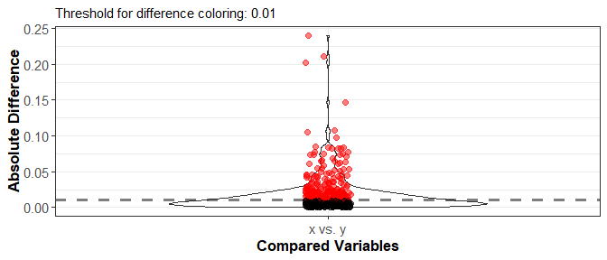